# Exercise 1: familiarize with R

Data Projects & Hackathon 2

# Introduction

```
plot(cars)
```

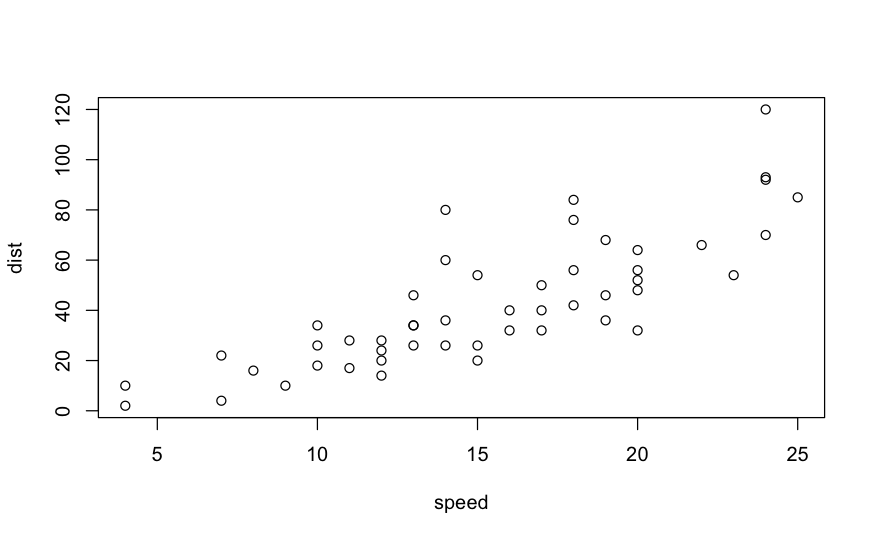

## Scalar operations

Try the following operations in R, assign the results to appropriate variables

- `4+3` assign the result to the variable `a`
- `a^2` assign the result to `b`
- `b` divided by 2
- `b` integer division by 2
- `b` modulo 2, assign the result to `c`
- Return a boolean that is `TRUE` if `c` is equal to zero

```
# Write your solutions here

c <- 1

bool_c <- c==1
```

## Vectors

### Pointwise operations

Build two vectors that contain measurements `x=[0.05, 1.51, -0.36, -0.14, 1.31, 0.11, -1.56, 0.13, -0.40, -0.31 ]` and use vector operations to compute

- the mean of `x`;
- the length of `x`;
- the empirical variance of `x` defined as $\frac{1}{n} \sum_{i=1}^n(x_i-\bar{x})^2$

```
# Write your solutions here
```

### Sequences and repeated vectors

Use the functions `seq` and `rep` to generate

- the vector of powers of two from 1 to 256
- the vector `[1 2 3 11 12 13 21 22 23 31 32 33]`

```
seq(0,8)
```

```
[1] 0 1 2 3 4 5 6 7 8
```

```
2^seq(0,8)
```

```
[1]   1   2   4   8  16  32  64 128 256
```

### Vector multiplications

Build the vectors `a= [3,2,1]` and `b=[2,-3,0]` and perform the following operations

- `a^T b`
- the outer product of `a` and `b`

```
# Write your solutions here
```

## Matrices

Create the following matrix

$S= \begin{bmatrix} 1 & 0.5 & 0.9 \\ 0.5 & 1 & 0.7 \\ 0.9 & 0.7 & 1 \end{bmatrix}$

and evaluate the following with R functions

- determinant of S
- trace of S (compose functions)
- the inverse of S
- given the vector `a=[1,2,3]`, compute `a^T S^{-1} a`

```
# Write your solutions here
```

## Lists and dataframes

Create a list `x` that contains

- the sequence of numbers from 2 to 5
- the string “Rolling Stones”
- the boolean `FALSE`
- another list that contains a vector with numbers 6 to 7 and the number 10 Access the boolean value by using the brakets notation

```
# Write your solutions here
```

### Data frames

- Build a dataset of TV series with the following attributes *Title*, *Year*, *Network* of size at least 4 and store it in a data.frame.
- Use the function `order` (see documentation) to obtain the ordering of the tv series by year
- Extract the oldest TV series in the data frame by using the bracket notation and by using the function `head`

```
# Write your solutions here
```

### Working with data frames

Cosider now the data frame `swiss` which is automatically loaded when opening R.

- look up the first entries with the function `head`, what do you think it is about?
- Use the help function to find more details on the data.
- Use the function `dim` to find out how many instances and how many features the data has.
- Use a for loop with an if statement to choose only the instances with the feature `Catholic`>50.
  - You can create an empty data frame with the function `data.frame()`
  - You can “append” a new row to the data frame with the function `rbind`
- Can you use obtain the same dataset with one line of code? Think about subsetting by evaluating an expression.

```
# Write your solutions here
```